# Eksperyment PD3

Wojciech Łukaszyk i Hubert Zagrajek

2023-03-28

## Opis eksperymentów

Podczas ankiety prezentowaliśmy ankietowanemu po dwa wykresy przedstawiąjące to samo zagadnienie. Następnie prośiliśmy o zaznaczenie pozytywnych cech każdego z wykresów. Ankietowani do wyboru mieli:

- czytelny
- łatwo znaleźć wartość najmienjszą i największą
- łatwo porównać dwi wartości
- pokazuje tylko istotne informacje
- posiada dobrze opisane osie
- estetyczny
- ospowiedni rodzaj wykresu do przedstawianych danych
- dobra skala osi

Na koniec prośiliśmy o wybranie tego z wykresów, który zdaniem ankietowanego był bardziej poprawny.

W eksperymencie wzięły udział 22 osoby.

### Eksperyment 1

W pierwszym eksperymencie stworzyliśmy dwa wykresy pokazujące liczbę samochodów z lat 2002-2012 w wybranych kolorach. Pierwszy wykres został stworzony przy użyciu współrzędnych biegunowych. W drugim użyliśmy współrzędnych kartezjańskich.

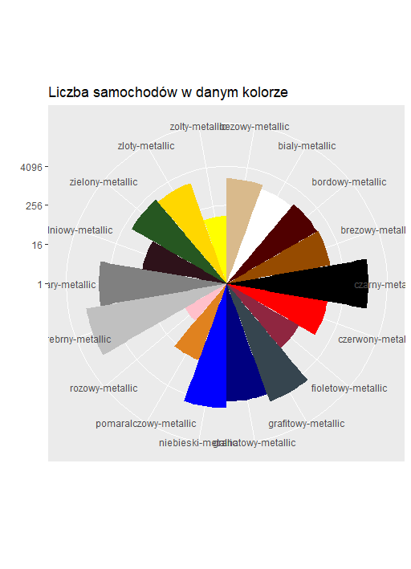

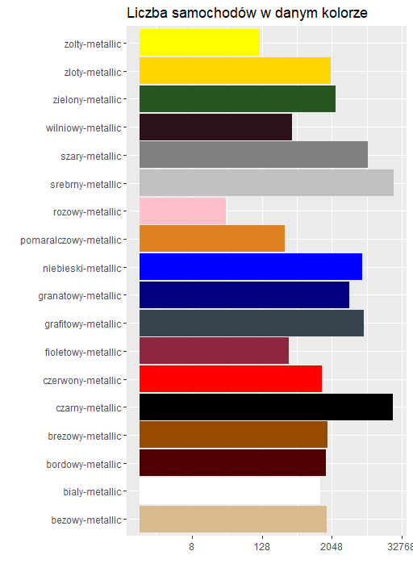

### Wyniki eskperymentu 1

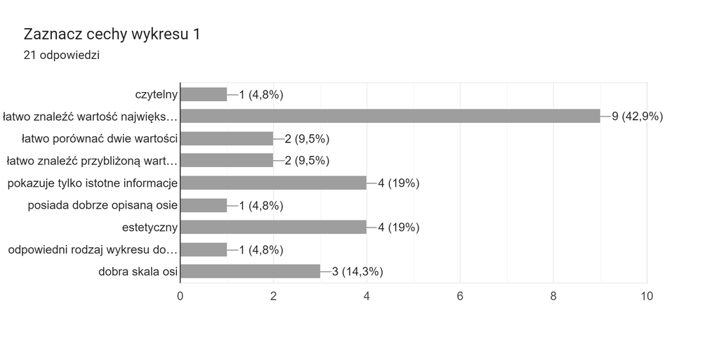

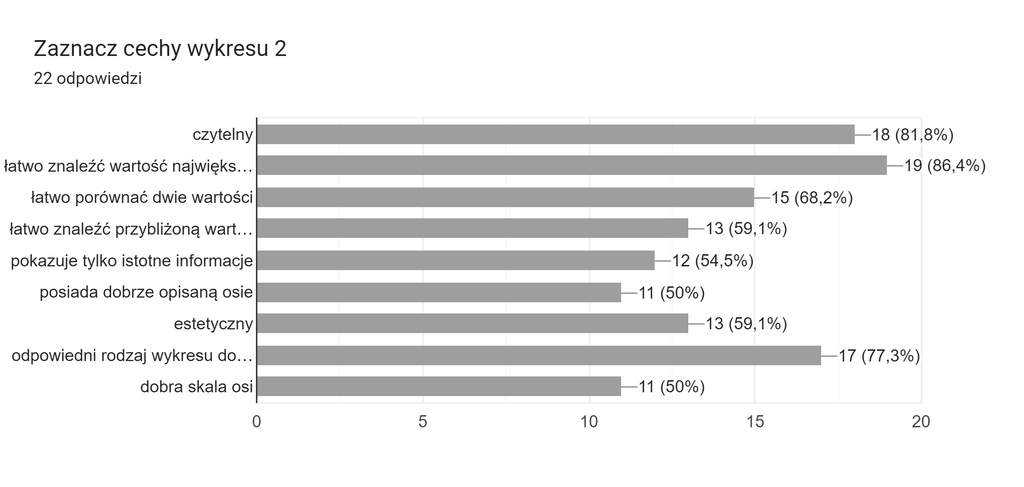

Łatwo zauważyć, że wykres ze współrzędnymi biegunowymi zebrał o wiele mniej pozytywnych ocen. Był on ciężki do odczytania i ogólnie nieczytelny. Wykres kolumnowy nie sprawiał takich trudności.

Wszyscy ankietowani stwierdzili, że wykres ze współrzędnymi kartezjańskimi jest bardziej poprawny.

### Eksperyment 2

W drugim eksperymencie stworzyliśmy dwa wykresy przedstaiwające medianę cen w zależności od roku produkcji samochodu. Obydwa wykresy są wykresami kolumnowymi, lecz pierwszy z nich (nazwany w ankiecie Wykres 3) ma wyraźnie lepiej opisane osie, tytuł pozwalający na stwierdzenie czego dotyczy wykres. Drugi (nazwany w ankiecie Wykres 4) nie posiada tytułu, a po nazwach osi nie jesteśmy w stanie jednoznacznie stwierdzić co wskazują.

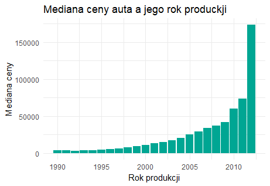

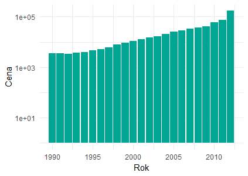

### Wyniku eksperymentu 2

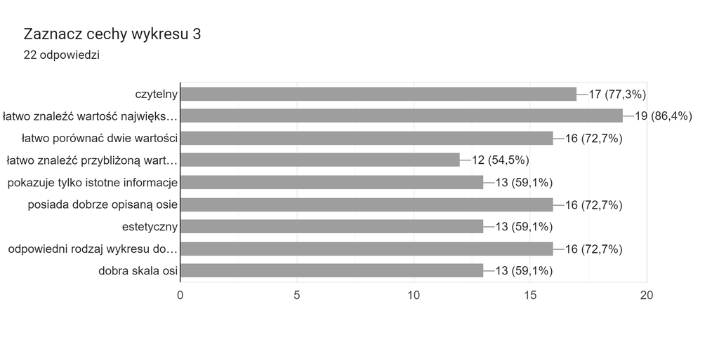

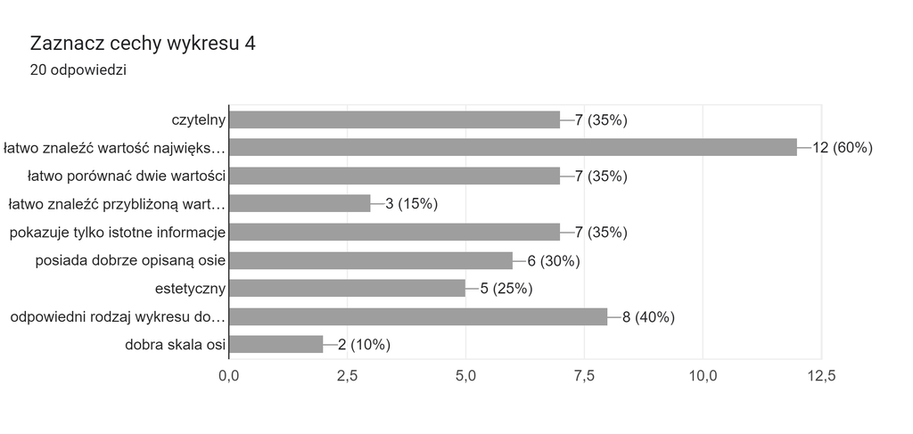

Dla większości ankietowanych wykres 3 był czytelniejszy, miał lepiej opisane osie, był bardziej estetyczny oraz miał lepiej przeskalowane osie.

Mimo tego dwie z osób ankietwanych jako bardziej poprawny, wskazało wykres 4.

## Wnioski

Analizując wyniki ankiety, można stwierdzić, że:

- współrzędne biegunowe się nie sprawdzają
- ważny jest dobry opis osi
- ważna jest zastosowanie dobrej skali
- prostota wykresu pomaga w czytelności

Zatem stare praktyki, sprawdzają się w społeczeństwie, które karmione jest wykresami od namłodszych lat.